# Joint species distribution GAMs with informed loadings

Nicholas J Clark

2026-06-26

A community of species rarely behaves as a collection of independent units. After accounting for measured environmental gradients, the residual co-occurrence between species still carries signal. Some of it is unmeasured climate or sampling artefact; some of it is shared phylogeny or biotic interaction. Joint Species Distribution Models (JSDMs) compress that residual covariance into a low-rank decomposition `Sigma = Z Zᵀ`, where `Z` is an `n_species x n_lv` loading matrix mapping each species to its position in a small latent space (Warton et al. [2015](https://doi.org/10.1016/j.tree.2015.09.007); Ovaskainen et al. [2017](https://doi.org/10.1111/ele.12757)). The latent positions double as an ordination, and the implied `Sigma` is the residual species correlation matrix.

mvgam’s `jsdgam()` function fits this class of model using the Heaps & Jermyn ([2024](https://doi.org/10.1007/s11222-024-10454-0)) identification scheme, which applies a QR decomposition to the sampled loadings inside generated quantities. The default prior treats the columns of `Z` as a priori exchangeable, but two extensions let domain knowledge enter directly. Species traits or a phylogeny can shape the prior on `Z` through an automatic relevance determination (ARD) kernel; functionally or phylogenetically similar species are pulled toward similar loadings before the data speaks. As an alternative to picking `n_lv` directly, a column shrinkage prior built from a multiplicative gamma process lets the data choose how many factors are active. We walk through both on the Australian ant trait dataset (Warton et al. [2015](https://doi.org/10.1016/j.tree.2015.09.007)).

## The data

`antTraits` ships with the `mvabund` package. It carries 30 sites x 41 ant species capture counts together with five environmental covariates (`Bare.ground`, `Canopy.cover`, `Shrub.cover`, `Volume.lying.CWD`, `Feral.mammal.dung`) and a five-column species trait table. The traits cover morphology (`Femur.length` and `Webers.length` for body size), defence (`No.spines`), pilosity and worker-caste polymorphism.

```r
data(antTraits, package = "mvabund")
str(antTraits, max.level = 1)
```

```
#> List of 3
#>  $ abund :'data.frame':  30 obs. of  41 variables:
#>  $ env   :'data.frame':  30 obs. of  5 variables:
#>  $ traits:'data.frame':  41 obs. of  5 variables:
```

```r
head(antTraits$abund[, 1:5])
```

```
#>   Amblyopone.australis Aphaenogaster.longiceps Camponotus.cinereus.amperei
#> 1                    0                       0                           0
#> 2                    0                       0                           0
#> 3                    0                       0                           0
#> 4                    4                       0                           0
#> 5                    2                       0                           0
#> 6                    0                       0                           1
#>   Camponotus.claripes Camponotus.consobrinus
#> 1                   2                      1
#> 2                   0                      4
#> 3                   0                      6
#> 4                   1                      1
#> 5                   4                      7
#> 6                   5                     11
```

```r
head(antTraits$env)
```

```
#>   Bare.ground Canopy.cover Shrub.cover Volume.lying.CWD Feral.mammal.dung
#> 1        9.00          3.5        0.50       0.03253833              0.20
#> 2        6.00          0.0        0.00       0.01202944              0.65
#> 3        9.25          0.0        8.10       0.00804195              0.00
#> 4       23.25          0.0        0.25       0.00000000              0.20
#> 5        8.75          0.0        3.35       0.00993944              0.35
#> 6       32.25          0.0        0.00       0.03142221              1.00
```

```r
head(antTraits$traits, 3)
```

```
#>                             Femur.length No.spines Pilosity Polymorphism
#> Amblyopone.australis         -0.38278140         0        2            1
#> Aphaenogaster.longiceps       0.15408686         2        1            0
#> Camponotus.cinereus.amperei   0.01135992         0        1            1
#>                             Webers.length
#> Amblyopone.australis            1.0942247
#> Aphaenogaster.longiceps         0.6740655
#> Camponotus.cinereus.amperei     0.6940704
```

Two of the trait columns (`Pilosity` and `Polymorphism`) ship as ordered factors with numeric levels. We coerce them to numeric so the ARD kernel reads them as ordered continuous traits rather than dummy-encoded categories.

```r
abund  <- antTraits$abund
env    <- antTraits$env
traits <- antTraits$traits
traits$Pilosity     <- as.numeric(as.character(traits$Pilosity))
traits$Polymorphism <- as.numeric(as.character(traits$Polymorphism))
```

`jsdgam()` expects long-form data with one row per site x species cell. We reshape, repeat the environmental covariates across species rows, and standardise the covariates so the linear coefficients sit on a comparable scale.

```r
n_sites   <- nrow(abund)
n_species <- ncol(abund)
species_names <- colnames(abund)

ant_long <- data.frame(
  site    = factor(rep(seq_len(n_sites), times = n_species)),
  species = factor(rep(species_names, each = n_sites),
                   levels = species_names),
  time    = rep(seq_len(n_sites), times = n_species),
  counts  = as.integer(unlist(abund))
)
ant_long <- cbind(ant_long, env[as.integer(ant_long$site), ])
for (col in colnames(env)) {
  ant_long[[col]] <- as.numeric(scale(ant_long[[col]]))
}
head(ant_long)
```

```
#>   site              species time counts Bare.ground Canopy.cover Shrub.cover
#> 1    1 Amblyopone.australis    1      0  -0.3991510    0.2329085  -0.5844021
#> 2    2 Amblyopone.australis    2      0  -0.8141327   -0.4550068  -0.8187880
#> 3    3 Amblyopone.australis    3      0  -0.3645692   -0.4550068   2.9782632
#> 4    4 Amblyopone.australis    4      4   1.5720124   -0.4550068  -0.7015951
#> 5    5 Amblyopone.australis    5      2  -0.4337328   -0.4550068   0.7515974
#> 6    6 Amblyopone.australis    6      0   2.8169576   -0.4550068  -0.8187880
#>   Volume.lying.CWD Feral.mammal.dung
#> 1        0.4446245        -0.1784634
#> 2       -0.2348288         1.5424337
#> 3       -0.3669332        -0.9433066
#> 4       -0.6333605        -0.1784634
#> 5       -0.3040699         0.3951690
#> 6        0.4076478         2.8809093
```

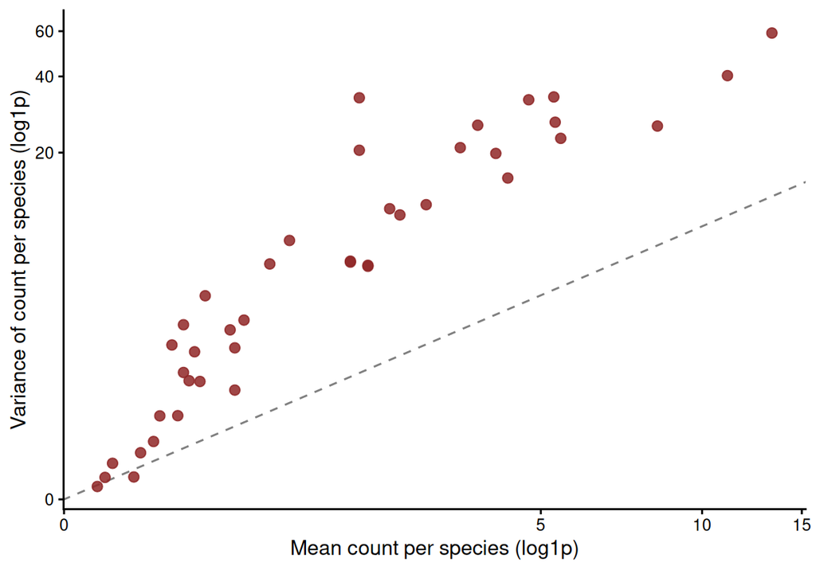

```r
red <- mvgam:::mvgam_palette("red")[5L]
per_sp <- do.call(rbind, tapply(
  ant_long$counts, ant_long$species,
  function(x) c(mean = mean(x), var = var(x))
))
per_sp <- as.data.frame(per_sp)
ggplot(per_sp, aes(x = mean, y = var)) +
  geom_abline(slope = 1, intercept = 0, linetype = "dashed",
              colour = "grey50") +
  geom_point(size = 2.2, alpha = 0.85, colour = red) +
  scale_x_continuous(trans = "log1p") +
  scale_y_continuous(trans = "log1p") +
  labs(x = "Mean count per species (log1p)",
       y = "Variance of count per species (log1p)") +
  mvgam:::mvgam_theme()
```

A negative binomial observation model accommodates that dispersion through its species-level `shape` parameter.

## A baseline JSDM: uninformed loadings

A useful first move is to fit the model with no trait information at all. The loadings have to find their structure from the data alone, which gives a clean reference point for asking what an informed prior adds afterwards. We keep the default loading prior: each entry of `Z` is independent under a weak `student_t(3, 0, 1)`. The latent space is two-dimensional (`n_lv = 2L`) and `factor_formula = ~ -1` asks for no smooths on the factors themselves. Counts get the `negbinomial()` family to absorb dispersion beyond a Poisson mean.

```r
mod_baseline <- jsdgam(
  formula = counts ~ Bare.ground + Canopy.cover + Shrub.cover +
    Volume.lying.CWD + Feral.mammal.dung,
  factor_formula = ~ -1,
  data    = ant_long,
  family  = negbinomial(),
  n_lv    = 2L,
  unit    = time,
  species = species,
  chains  = 2L, samples = 600L, silent = 2L
)
```

```r
summary(mod_baseline, smooth_test = FALSE)
```

```
#>  Family: negbinomial
#>   Links: mu = log
#> Formula: counts ~ Bare.ground + Canopy.cover + Shrub.cover + Volume.lying.CWD +     Feral.mammal.dung
#>    Data: <inline data> (Number of observations: 1230)
#>  Series: 41
#>  Trends: ZMVN(); formula: ~0
#>   Draws: 2 chains, each with iter = 1000; warmup = 500; thin = 1;
#>          total post-warmup draws = 2000
#>
#> == Observation Model ==
#> Population-Level Effects:
#>           Estimate Est.Error l-95% CI u-95% CI Rhat Bulk_ESS Tail_ESS
#> Intercept     1.38      0.18     1.02     1.73    1   506.45   587.01
#>
#> Further Distributional Parameters:
#>       Estimate Est.Error l-95% CI u-95% CI Rhat Bulk_ESS Tail_ESS
#> shape     0.86      0.08     0.71     1.03    1  1270.81  1433.93
#>
#> == Trend Model ==
#> Factor Loadings: 82 entries. Use `shared_variation(fit)` for the series-level shared-variation summary.
#>
#> Draws were sampled using sampling(NUTS). For each parameter, Bulk_ESS
#> and Tail_ESS are effective sample size measures, and Rhat is the potential
#> scale reduction factor on split chains (at convergence, Rhat = 1).
#>
#> Next steps:
#>   - `pp_check(fit)`: posterior predictive checks
#>   - `shared_variation(fit)`: factor-implied Delta = Z Z' (rotation-invariant)
#>   - `residual_cor(fit)`: implied cross-series correlations
#>   - `loo(fit)` / `loo_compare(...)`: model fit + comparison
#> Use `how_to_cite(fit)` for a citation-ready model description.
```

```r
posterior_summary(mod_baseline)[paste0("b_", c(
  "Bare.ground", "Canopy.cover", "Shrub.cover",
  "Volume.lying.CWD", "Feral.mammal.dung"
)), c("Estimate", "Q2.5", "Q97.5")]
```

```
#>                         Estimate        Q2.5      Q97.5
#> b_Bare.ground        0.060133862 -0.05733129 0.18750624
#> b_Canopy.cover      -0.168141155 -0.34173689 0.01157742
#> b_Shrub.cover        0.105723606 -0.01952348 0.22736560
#> b_Volume.lying.CWD   0.004208533 -0.13954652 0.15676088
#> b_Feral.mammal.dung  0.061146168 -0.06702377 0.18179843
```

All five environmental coefficients have credible intervals straddling zero on the log scale of the linear predictor. The mean component is doing very little work in this baseline fit; the bulk of the between-site structure lives in the residual factor space, which the biplot below visualises.

Calling `ordinate()` returns a biplot. Site scores and species loadings are taken at the posterior median and the axes are rotated to a singular-value basis, so the first axis carries the dominant ordination gradient.

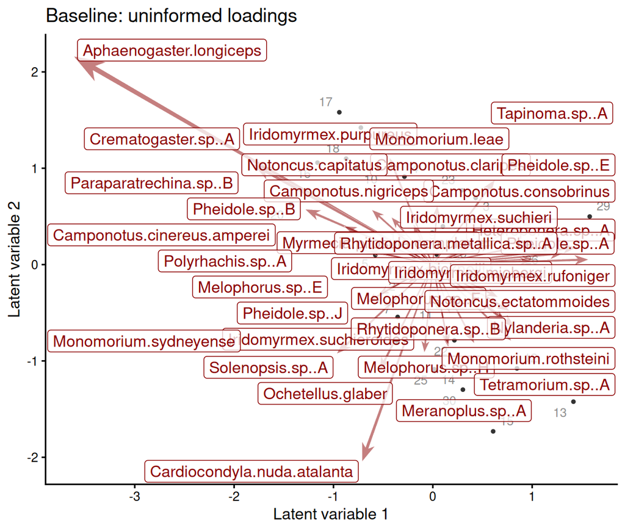

```r
ordinate(mod_baseline) +
  ggtitle("Baseline: uninformed loadings")
```

Two species sit at the extremes of LV2 (`Aphaenogaster.longiceps` high, `Cardiocondyla.nuda.atalanta` low) with the rest of the community clustered near the origin. Nothing in the layout references trait similarity yet, because the prior had no reason to encode any. Before reading further into the ordination it pays to confirm the observation layer fits the counts. Calling `pp_check(mod_baseline)` dispatches to `pp_check.mvgam()` for that diagnostic: a misfit on the zero counts or on the upper tail means the family is wrong, and fixing that takes priority over any ecological reading of the biplot.

## Heaps-architecture trait-informed loadings

The Heaps & Jermyn ([2024](https://doi.org/10.1007/s11222-024-10454-0)) architecture replaces the iid loadings prior with a structured one. Each column of `Z` is drawn from `multi_normal_cholesky(0, L_Φ · √Ψ_diag[k])`, where the covariance `Φ` is built by an ARD kernel on a feature matrix supplied by the user. The kernel estimates one inverse scale per feature column. Features that predict co-occurrence pull the relevant species toward similar loadings; features that do not predict it shrink to large scales and contribute little. For species traits the result is a prior that says “ants whose body size and defensive traits are similar start out near each other in latent space, before seeing the counts.”

Passing the trait table via the `traits =` alias is the only change to the call.

```r
mod_traits <- jsdgam(
  formula = counts ~ Bare.ground + Canopy.cover + Shrub.cover +
    Volume.lying.CWD + Feral.mammal.dung,
  factor_formula = ~ -1,
  data    = ant_long,
  family  = negbinomial(),
  n_lv    = 2L,
  traits  = traits,
  unit    = time,
  species = species,
  chains  = 2L, samples = 600L,
  adapt_delta = 0.95, silent = 2L
)
```

We bump `adapt_delta` from the Stan default of 0.8 to 0.95. The ARD geometry on 41 species and 5 trait columns has a funnel where the kernel scales hand off prior mass to the loadings; the tighter leapfrog step keeps the sampler from skipping over it.

```r
summary(mod_traits, smooth_test = FALSE)
```

```
#>  Family: negbinomial
#>   Links: mu = log
#> Formula: counts ~ Bare.ground + Canopy.cover + Shrub.cover + Volume.lying.CWD +     Feral.mammal.dung
#>    Data: <inline data> (Number of observations: 1230)
#>  Series: 41
#>  Trends: ZMVN(); formula: ~0
#>   Draws: 2 chains, each with iter = 1000; warmup = 500; thin = 1;
#>          total post-warmup draws = 2000
#>
#> == Observation Model ==
#> Population-Level Effects:
#>           Estimate Est.Error l-95% CI u-95% CI Rhat Bulk_ESS Tail_ESS
#> Intercept     1.73      0.21     1.35     2.15    1   497.13   760.29
#>
#> Further Distributional Parameters:
#>       Estimate Est.Error l-95% CI u-95% CI Rhat Bulk_ESS Tail_ESS
#> shape     0.91      0.09     0.75     1.09    1  1010.46  1070.25
#>
#> == Trend Model ==
#> Factor Loadings: 82 entries. Use `shared_variation(fit)` for the series-level shared-variation summary.
#>
#> Loadings Prior (length-scales: smaller => stronger influence on Delta = Z * Z'; larger => weaker):
#>                   Estimate Est.Error l-95% CI u-95% CI Rhat Bulk_ESS Tail_ESS
#> theta_features[1]     0.54      0.28     0.18     1.21 1.00   936.01  1214.76
#> theta_features[2]     3.16      4.01     0.41    13.84 1.00  1350.47  1574.61
#> theta_features[3]     2.98      2.34     0.66     9.22 1.01  1016.79   933.84
#> theta_features[4]     2.46      2.24     0.41     8.52 1.00  1644.99  1339.23
#> theta_features[5]     2.46      2.48     0.47     8.56 1.00   824.38  1067.60
#>
#> Draws were sampled using sampling(NUTS). For each parameter, Bulk_ESS
#> and Tail_ESS are effective sample size measures, and Rhat is the potential
#> scale reduction factor on split chains (at convergence, Rhat = 1).
#>
#> Next steps:
#>   - `pp_check(fit)`: posterior predictive checks
#>   - `shared_variation(fit)`: factor-implied Delta = Z Z' (rotation-invariant)
#>   - `residual_cor(fit)`: implied cross-series correlations
#>   - `loo(fit)` / `loo_compare(...)`: model fit + comparison
#> Use `how_to_cite(fit)` for a citation-ready model description.
```

Reading `theta_features[k]` follows the standard ARD convention. The kernel takes the form `exp(-||(x_i - x_j) / theta||^2)`. A posterior `theta_features[k]` that is small relative to the spread of trait `k` says the kernel decays sharply along that dimension, which pulls trait-different species apart in the latent space. A posterior length scale much larger than the trait spread says the kernel barely changes with that trait, so the data has effectively dropped it from the loadings prior. The Heaps & Jermyn ([2024](https://doi.org/10.1007/s11222-024-10454-0)) prior expresses the ARD covariance across species through the matrix `Phi` and ties it to the observable shared variation `Delta = Z Zᵀ` via the identity `E(Delta) = tr(Psi^2) * Phi`. The function `shared_variation()` returns posterior summaries of `Delta` directly when those magnitudes matter.

The biplot, this time with `traits = "auto"` to overlay each trait’s regression onto the rotated loadings, makes the restructuring visible.

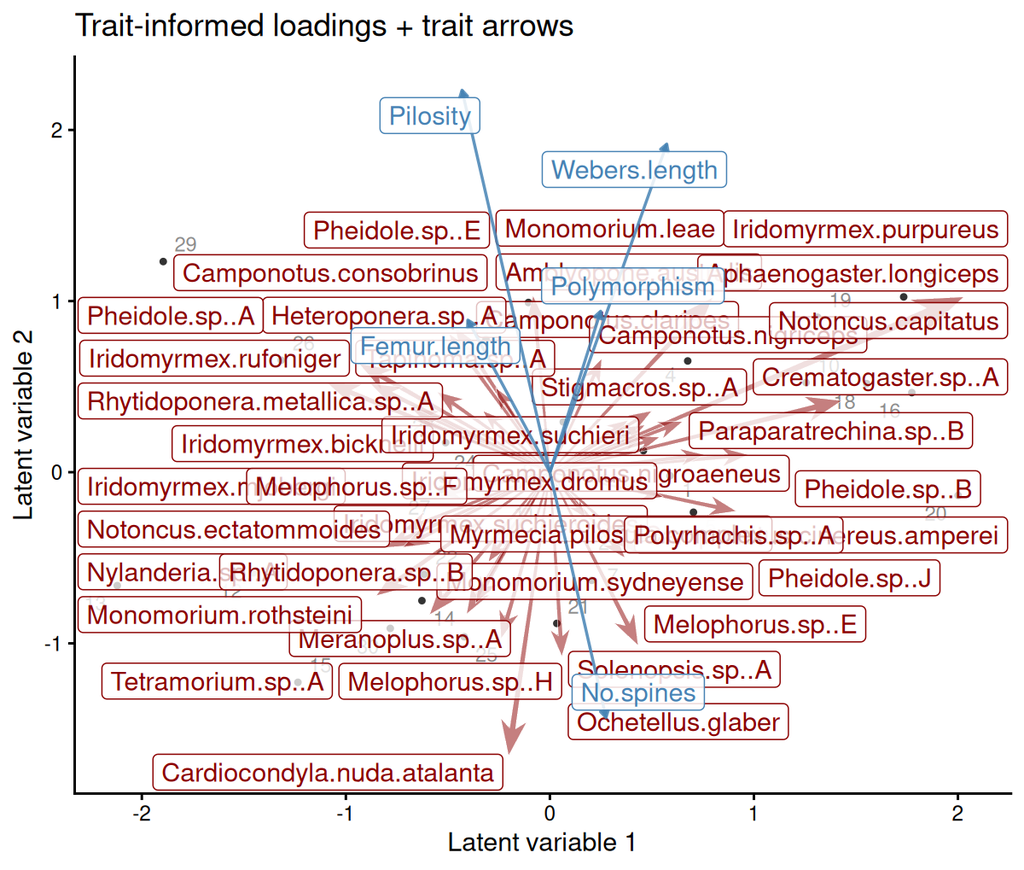

```r
ordinate(mod_traits, rotation = "varimax", traits = "auto") +
  ggtitle("Trait-informed loadings + trait arrows")
```

Four of the trait arrows point into the upper portion of the biplot (`Pilosity`, `Webers.length`, `Polymorphism` and `Femur.length`), where the larger-bodied `Camponotus` and `Iridomyrmex purpureus` cluster sits. `No.spines` is the only arrow pointing downward, into the region occupied by `Cardiocondyla.nuda.atalanta`, `Solenopsis.sp..A`, `Meranoplus.sp..A` and other smaller species. The latent space has acquired an ecological gradient that the baseline fit did not have: body size and defensive armature pulling in opposite directions along LV2.

`compare_loadings()` makes the effect on individual species explicit. The two fits sit in independent QR bases. The function applies an orthogonal Procrustes rotation that brings the second fit into the basis of the first, then draws a segment from each species’ baseline position to its position under the trait prior.

```r
compare_loadings(
  mod_baseline, mod_traits,
  labels = c("uninformed", "trait-informed"),
  label_species = "shift"
)
```

[figure not shown]

## Identification: rotations of the latent basis

The factor model is identified only up to rotation of the latent space. Any orthogonal rotation of the columns of `Z`, paired with the inverse rotation of the latent factor scores, produces the same likelihood. The Stan model samples unconstrained `Z` and applies a thin QR decomposition in generated quantities. The result is a `Z_tilde` that is lower-triangular with positive diagonal entries (Heaps & Jermyn [2024](https://doi.org/10.1007/s11222-024-10454-0)). That is what `ordinate()` reads by default. Different rotations applied after fitting re-express the same posterior on axes that are easier to interpret for different questions.

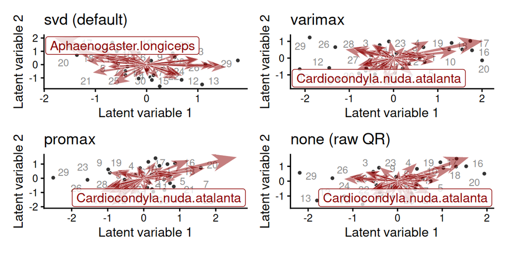

```r
p_svd <- ordinate(mod_traits, rotation = "svd") +
  ggtitle("svd (default)")
p_vmx <- ordinate(mod_traits, rotation = "varimax") +
  ggtitle("varimax")
p_pro <- ordinate(mod_traits, rotation = "promax") +
  ggtitle("promax")
p_non <- ordinate(mod_traits, rotation = "none") +
  ggtitle("none (raw QR)")
(p_svd | p_vmx) / (p_pro | p_non)
```

The `svd` rotation reorders axes by singular-value variance and matches the BORAL convention (Hui [2016](https://doi.org/10.1111/2041-210X.12514)). The `varimax` and `promax` rotations target loading sparsity. Each makes per-axis interpretation cleaner when individual species tend to load on one factor more than the others. The `none` option plots the raw identified loadings. All four panels show the same fit. The choice between them is about which axis interpretation suits the question at hand. See `?ordinate.jsdgam` for the full set of plotting arguments (including `alpha` for the BORAL site / loading variance split, and `label_sites` for switching between text and point markers); `plot_factors()` is the lower-level companion that draws the unrotated identified factors as time series.

## Residual species correlations

The factor decomposition implies a residual species covariance `Sigma = Z Zᵀ` after accounting for the measured environment. `residual_cor()` returns posterior summaries of this matrix, with entries set to zero where the credible interval covers zero. The `cluster = TRUE` argument reorders rows and columns by an approximate Robinson ordering so block structure shows up on the diagonal. The companion accessor `shared_variation()` returns the full posterior over the covariance matrix itself, useful when entry magnitudes matter for downstream analysis; both surface entry-level posterior probabilities via `summary()` on the returned object.

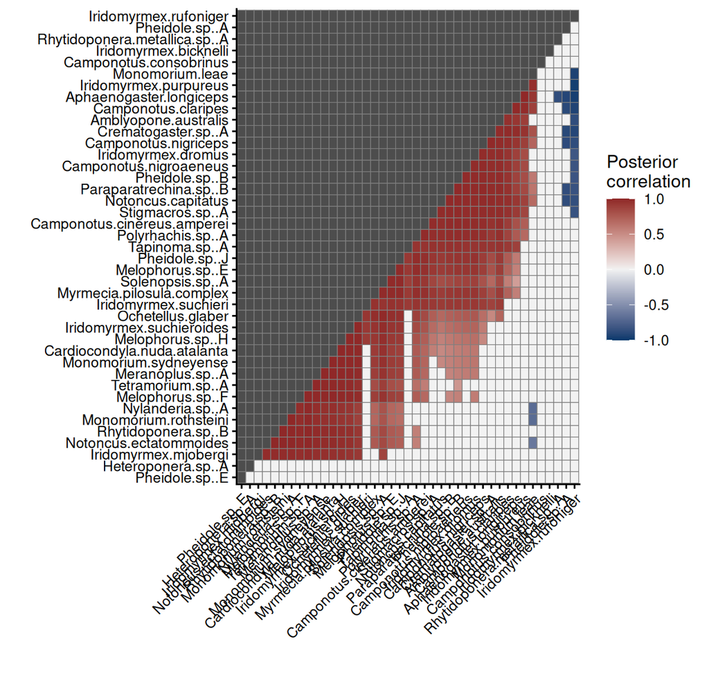

```r
rcor <- residual_cor(mod_traits, summary = TRUE)
plot(rcor, cluster = TRUE)
```

Three large positive blocks line up on the diagonal: groups of species that tend to co-occur once the environment is accounted for. A clear band of negative correlation cuts across the heatmap on `Iridomyrmex.rufoniger`. Its top five strongest negative residual correlations are all with high-abundance species elsewhere in the community (`Iridomyrmex.purpureus`, `Aphaenogaster.longiceps`, `Monomorium.leae`, `Pheidole.sp..A`, `Camponotus.claripes`), each below -0.88. Its loadings sit in a region of the latent space that the rest of the community avoids, which is consistent with competitive dominance or with an unmeasured environmental contrast that we have not conditioned on.

Residual correlation is *evidence consistent with* shared unmeasured drivers, not proof of any specific mechanism. A positive entry can reflect either a shared unmeasured niche or a simultaneous detection bias on the two species; a negative entry can reflect competition or an environmental gradient the model did not condition on. The factor model gives us a coherent posterior over the matrix but does not adjudicate between these explanations on its own.

## How many factors? Data-driven dimensionality with MGP

The fits so far pinned `n_lv = 2L`. A more principled choice is to set a ceiling and let the posterior decide. The multiplicative gamma process (MGP) prior of Bhattacharya & Dunson ([2011](https://doi.org/10.1093/biomet/asr013)) puts increasing shrinkage on later columns of `Z`. Only the leading few columns carry mass under the prior, and the data shifts that envelope as needed. Legramanti, Durante & Dunson ([2020](https://doi.org/10.1093/biomet/asaa008)) propose a cumulative shrinkage criterion for declaring a factor active.

Passing the MGP spec through `loadings_prior` composes cleanly with the trait kernel. Traits supply the ARD covariance across species within each column; MGP supplies the shrinkage across columns.

```r
mod_mgp <- jsdgam(
  formula = counts ~ Bare.ground + Canopy.cover + Shrub.cover +
    Volume.lying.CWD + Feral.mammal.dung,
  factor_formula = ~ -1,
  data    = ant_long,
  family  = negbinomial(),
  n_lv    = 10L,
  loadings_prior = list(column_shrinkage = "mgp", features = traits),
  unit    = time,
  species = species,
  chains  = 2L, samples = 600L, silent = 2L
)
```

`active_factors()` summarises the posterior distribution of how many factors clear the activity threshold. The default threshold marks factor `k` as active when the posterior probability that its squared column-norm exceeds 1% of the leading column’s norm is at least 0.5.

```r
af <- active_factors(mod_mgp)
af
```

```
#> Active latent factors (Legramanti / Durante / Dunson 2020 criterion)
#>   Truncation ceiling: n_lv = 10
#>   Posterior median active count: 6.0 (95% CI 4.0 - 9.0)
#>   Threshold: epsilon = 1.7619 (= 0.01 x leading-column posterior mean norm^2)
#>
#> Per-column posterior probability of being active:
#>  factor prob_active median_norm_sq is_active
#>       1       1.000       130.5268      TRUE
#>       2       1.000        62.5635      TRUE
#>       3       0.998        47.4101      TRUE
#>       4       0.932        15.7098      TRUE
#>       5       0.848         8.6406      TRUE
#>       6       0.705         4.2658      TRUE
#>       7       0.484         1.6226     FALSE
#>       8       0.353         0.8517     FALSE
#>       9       0.094         0.1656     FALSE
#>      10       0.035         0.0551     FALSE
```

Plotting the same object gives the per-factor probability bars with the activity cutoff shown as a dashed line, plus the posterior median and 95% CI of the active count in the subtitle.

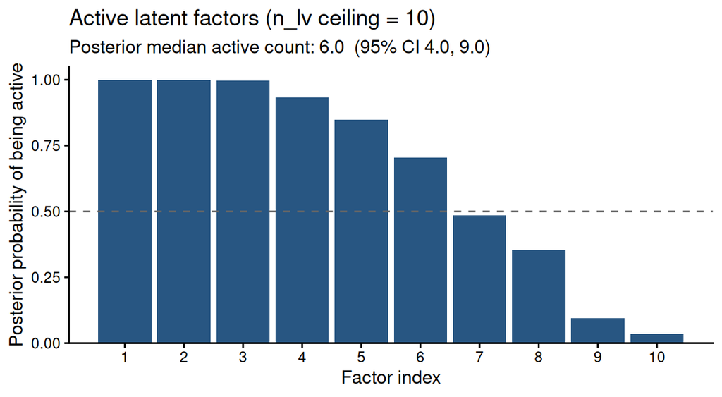

```r
plot(af)
```

## Take-aways

A negative binomial JSDM with Heaps-identified loadings gives a single coherent posterior over the environmental responses, the latent factor scores, the species loadings and the implied residual species correlation matrix. The observation family chooses how counts disperse: `family = negbinomial()` was the right pick here. The loadings prior carries the domain knowledge: passing `traits =` (or `phylo =`) routes that knowledge through an ARD kernel, so functionally similar species cluster a priori before the data speaks. And the factor count is rarely known up front, so reach for `loadings_prior = list(column_shrinkage = "mgp", ...)` to let the posterior shrink later columns of `Z` and surface the active count via `active_factors()`.

## Further reading

Three extensions sit outside the scope of this article and deserve their own write-ups. The `phylo =` argument accepts an `ape::phylo` object or a pairwise distance matrix and builds the ARD kernel from phylogenetic distance rather than from trait similarity; that route is useful when the available signal is evolutionary rather than morphological. The `trait_slopes =` argument implements the trait-mediated regression of Pollock et al. ([2012](https://doi.org/10.1111/j.1600-0587.2011.07085.x)) and the Hmsc framework of Tikhonov et al. ([2020](https://doi.org/10.1111/2041-210X.13345)): each species’ environmental response is itself regressed on traits. That complements the loadings story by modelling how trait similarity shapes responses to measured environment, not just residual co-occurrence. Finally, the `occ()` family marginalises imperfect detection at the closure-unit level for joint occupancy fits; `?jsdgam` shows a worked example.

The rest of the workflow is the standard mvgam machinery applied to a jsdgam fit. To confirm the count layer absorbs the dispersion, `pp_check.mvgam()` runs the usual posterior predictive battery. To compare loadings priors on the same data, reach for `loo.mvgam()` as the cheap first pass and `kfold.mvgam()` when LOO Pareto-k goes red. To interrogate how an environmental gradient drives abundance once the factors have absorbed the residual structure between species, `conditional_effects()` plots the marginal means on the response scale. And when writing the methods section, `how_to_cite(mod_traits)` returns the citation paragraph that names the architecture pieces the fit actually used. The `?jsdgam` page covers the remaining options, including `lv_axis()` for per-factor smooths inside `factor_formula`.

## Acknowledgements

The `antTraits` data are released with the `mvabund` package (Wang et al. [2012](https://doi.org/10.1111/j.2041-210X.2012.00190.x)). The factor model architecture follows Heaps & Jermyn ([2024](https://doi.org/10.1007/s11222-024-10454-0)). The MGP prior is Bhattacharya & Dunson ([2011](https://doi.org/10.1093/biomet/asr013)) with the active-count criterion of Legramanti, Durante & Dunson ([2020](https://doi.org/10.1093/biomet/asaa008)).

## References

Bhattacharya A and Dunson DB (2011). Sparse Bayesian infinite factor models. *Biometrika* 98(2), 291-306. [doi:10.1093/biomet/asr013](https://doi.org/10.1093/biomet/asr013)

Heaps SE and Jermyn IH (2024). Structured prior distributions for the covariance matrix in latent factor models. *Statistics and Computing* 34, 143. [doi:10.1007/s11222-024-10454-0](https://doi.org/10.1007/s11222-024-10454-0)

Hui FKC (2016). boral - Bayesian Ordination and Regression Analysis of Multivariate Abundance Data in R. *Methods in Ecology and Evolution* 7(6), 744-750. [doi:10.1111/2041-210X.12514](https://doi.org/10.1111/2041-210X.12514)

Legramanti S, Durante D and Dunson DB (2020). Bayesian cumulative shrinkage for infinite factorizations. *Biometrika* 107(3), 745-752. [doi:10.1093/biomet/asaa008](https://doi.org/10.1093/biomet/asaa008)

Ovaskainen O, Tikhonov G, Norberg A, Blanchet FG, Duan L, Dunson D, Roslin T and Abrego N (2017). How to make more out of community data? A conceptual framework and its implementation as models and software. *Ecology Letters* 20(5), 561-576. [doi:10.1111/ele.12757](https://doi.org/10.1111/ele.12757)

Pollock LJ, Morris WK and Vesk PA (2012). The role of functional traits in species distributions revealed through a hierarchical model. *Ecography* 35(8), 716-725. [doi:10.1111/j.1600-0587.2011.07085.x](https://doi.org/10.1111/j.1600-0587.2011.07085.x)

Tikhonov G, Opedal OH, Abrego N, Lehikoinen A, de Jonge MMJ, Oksanen J and Ovaskainen O (2020). Joint species distribution modelling with the R-package Hmsc. *Methods in Ecology and Evolution* 11(3), 442-447. [doi:10.1111/2041-210X.13345](https://doi.org/10.1111/2041-210X.13345)

Wang Y, Naumann U, Wright ST and Warton DI (2012). mvabund - an R package for model-based analysis of multivariate abundance data. *Methods in Ecology and Evolution* 3(3), 471-474. [doi:10.1111/j.2041-210X.2012.00190.x](https://doi.org/10.1111/j.2041-210X.2012.00190.x)

Warton DI, Blanchet FG, O’Hara RB, Ovaskainen O, Taskinen S, Walker SC and Hui FKC (2015). So many variables: joint modeling in community ecology. *Trends in Ecology and Evolution* 30(12), 766-779. [doi:10.1016/j.tree.2015.09.007](https://doi.org/10.1016/j.tree.2015.09.007)